# Project 1: Roulette

[Roulette](https://en.wikipedia.org/wiki/Roulette#Bet_odds_table) is an iconic game of chance, where gamblers bet on numbers selected by a ball rolling into a slot of a rotating wheel. There are various styles of wheels, but in the US the most common is the “double-zero wheel”.

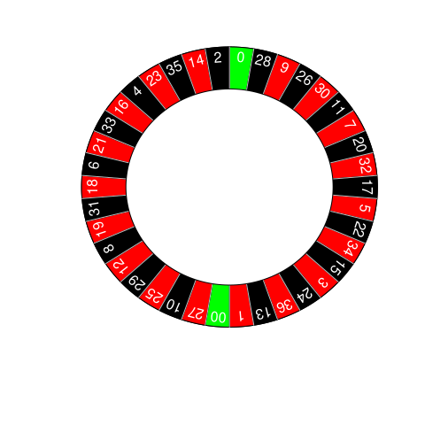

The double-zero wheel wheel has 38 slots. A gambler can choose [various categories](https://en.wikipedia.org/wiki/Roulette#Bet_odds_table) to bet on. In this paper, we will focus on two kinds of bets: straight-up and black. On a straight-up bet, the gambler chooses a specific number. On a black bet, the gambler bets the ball will select a black slot. Our gambler bets $1.00 on each spin.

For each betting style, we simulate 34 spins. This choice of 34 has two reasons: it is not used elsewhere in this paper to mean something else and it nearly maximizes the probability that a straight-up gambler will be ahead that day. (35 would maximize the chance a straight-up gambler would be ahead that day, but it also is the profit on a winning spin, so a reader may confuse the two.)

### Straight-up probability distribution

When betting straight up, there is a 1/38 chance of profiting $35 and a 37/38 chance of profiting -$1.00.

| Profit | Probability |
| --- | --- |
| -$1 | $\frac{37}{38}$ |
| $35 | $\frac{1}{38}$ |

We calculate the population mean.
$$\mu = \sum \text{profit} \times \text{probability}$$

```r
profit1 = c(-1, 35)
probs1 = c(37/38, 1/38)
mu1 = sum(profit1 * probs1)
```

```r
sigma1 = sum((profit1-mu1)^2 * probs1)
```

$$\sigma_1 = 33.2077562$$

### Bet-on-black probability distribution

When betting on black, there is a 18/38 chance of profiting $1 and a 20/38 chance of profiting -$1.00.

| Profit | Probability |
| --- | --- |
| -$1 | $\frac{20}{38}$ |
| $1 | $\frac{18}{38}$ |

We calculate the population mean.

```r
profit2 = c(-1, 1)
probs2 = c(20/38, 18/38)
mu2 = sum(profit2 * probs2)
```

```r
sigma2 = sum((profit2-mu2)^2 * probs2)
```

$$\sigma_2 = 0.9972299$$